# Megan Lott Visualization Exercise

Megan Lott

September 24, 2019

The original figure is from Five Thirty Eight’s article [“Are White Evangelicals Sacrificing The Future In Search Of The Past?”](https://fivethirtyeight.com/features/are-white-evangelicals-sacrificing-the-future-in-search-of-the-past/) posted January 24, 2018.

[figure not shown]

The original data was retrieved from the Public Religion Research Institute (PRRI) and included in the organizations’ report [“America’s Changing Religious Identity”](https://www.prri.org/research/american-religious-landscape-christian-religiously-unaffiliated/) from September 6, 2017. PRRI provided a figure of their own this this data. The data is availible for download as a .csv file.

[figure not shown]

```r
library(plotly)
library(knitr)
library(tidyverse)
library(ggplot2)
library(ggthemes)
library(RColorBrewer)
library(DT)
```

```r
#rename data set
religion_data = read_csv("C:/Users/13216/Desktop/MADA/meganlott-visualization/a-generational-shift-in.csv")
kable(religion_data)
```

| Source: PRRI 2016 American Values Atlas. | Don’t know/Refused | Unaffiliated | Other religion | Other world religions | Jewish | Other Christian | Hispanic Catholic | Hispanic Protestant | Black Protestant | Mormon | White Catholic | White mainline Protestant | White evangelical Protestant |
| --- | --- | --- | --- | --- | --- | --- | --- | --- | --- | --- | --- | --- | --- |
| 18-29 | 3 | 38 | 1 | 4 | 1 | 7 | 9 | 6 | 7 | 2 | 6 | 8 | 8 |
| 30-49 | 3 | 26 | 1 | 3 | 1 | 6 | 10 | 5 | 8 | 2 | 9 | 11 | 14 |
| 50-64 | 3 | 18 | 1 | 1 | 2 | 6 | 6 | 2 | 9 | 2 | 15 | 15 | 21 |
| 65+ | 3 | 12 | 1 | 1 | 2 | 5 | 4 | 1 | 7 | 2 | 16 | 19 | 26 |

```r
#rename age column

names(religion_data)[1]<-"age_group"

#the original data set is not tidy. The variables are: religion and age. There are counts or percentages for each group.
religion_data_tidy = religion_data %>% gather(key = "religion", value = "percent", -`age_group`)
datatable(religion_data_tidy, options = list(pageLength = 5))
```

|  | age_group | religion | percent |
| --- | --- | --- | --- |
| 1 | 18-29 | Don't know/Refused | 3 |
| 2 | 30-49 | Don't know/Refused | 3 |
| 3 | 50-64 | Don't know/Refused | 3 |
| 4 | 65+ | Don't know/Refused | 3 |
| 5 | 18-29 | Unaffiliated | 38 |
| 6 | 30-49 | Unaffiliated | 26 |
| 7 | 50-64 | Unaffiliated | 18 |
| 8 | 65+ | Unaffiliated | 12 |
| 9 | 18-29 | Other religion | 1 |
| 10 | 30-49 | Other religion | 1 |

[output cut: 42 more lines]

The figure from Five Thirty Eight is a bar plot that shares the religious identitity of respondants as a percentage of total respondants questions (proportions). The responses are binned by age group and colored by religious identity.

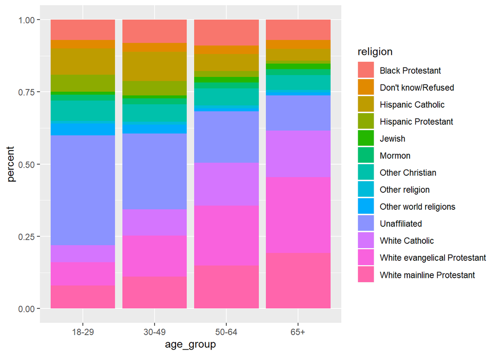

```r
religion_data_tidy %>%
ggplot(aes(fill= religion, y= percent, x=age_group)) +
    geom_bar(position="fill", stat="identity")
```

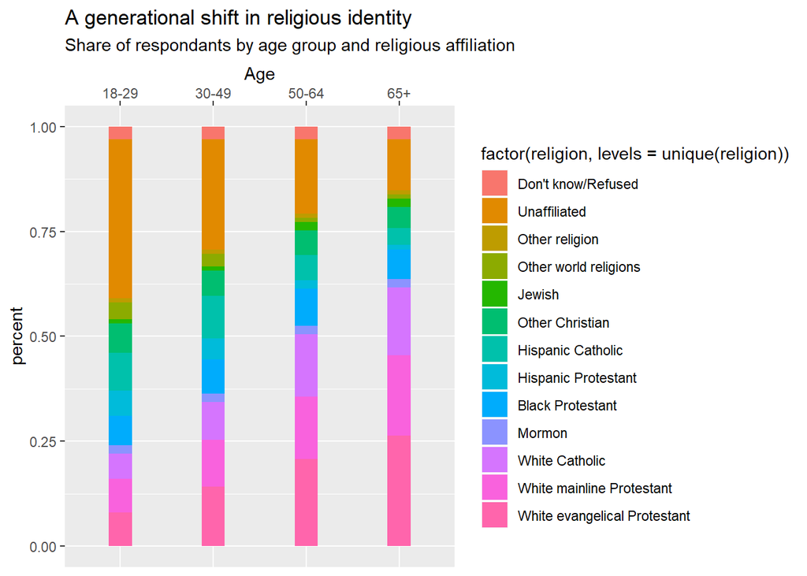

```r
religion_data_tidy %>%
ggplot(aes(fill= factor(religion, levels=unique(religion)), y= percent, x=age_group)) +
    geom_bar(position="fill", stat="identity", width = 0.25) +
    xlab("Age") +
    ggtitle("A generational shift in religious identity", subtitle = "Share of respondants by age group and religious affiliation") +
    scale_x_discrete(position = "top")
```

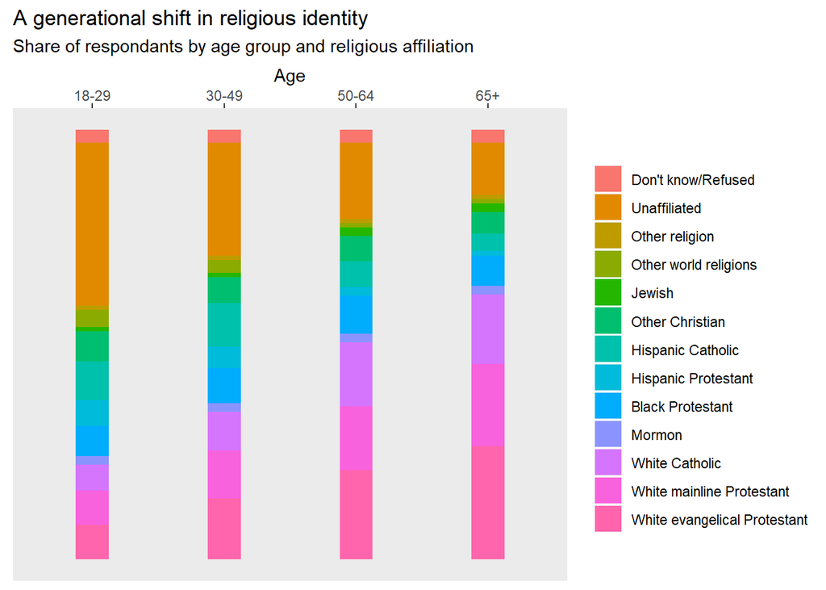

```r
religion_data_tidy %>%
ggplot(aes(fill= factor(religion, levels=unique(religion)), y= percent, x=age_group)) +
    geom_bar(position="fill", stat="identity", width = 0.25) +
    xlab("Age") +
    ggtitle("A generational shift in religious identity", subtitle = "Share of respondants by age group and religious affiliation") +
    scale_x_discrete(position = "top")+
    theme(axis.title.y = element_blank(), axis.text.y = element_blank(), axis.ticks.y = element_blank(),
    panel.grid.major = element_blank(), panel.grid.minor = element_blank()) +
    guides(fill=guide_legend(title=NULL))
```

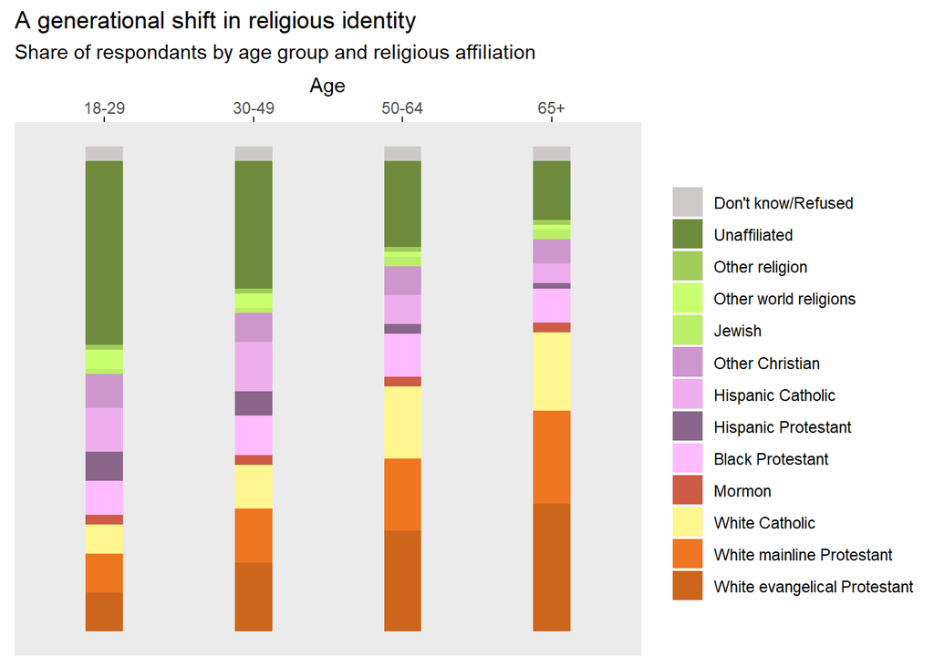

```r
religion_data_tidy %>%
ggplot(aes(fill= factor(religion, levels=unique(religion)), y= percent, x=age_group)) +
    geom_bar(position="fill", stat="identity", width = 0.25) +
    xlab("Age") +
    ggtitle("A generational shift in religious identity", subtitle = "Share of respondants by age group and religious affiliation") +
    scale_x_discrete(position = "top")+
    theme(axis.title.y = element_blank(), axis.text.y = element_blank(), axis.ticks.y = element_blank(),
    panel.grid.major = element_blank(), panel.grid.minor = element_blank()) +
    guides(fill=guide_legend(title=NULL)) +
  scale_fill_manual(values=c("snow3","darkolivegreen4", "darkolivegreen3","darkolivegreen1", "darkolivegreen2", "plum3", "plum2", "plum4", "plum1","coral3","khaki1", "chocolate2", "chocolate3"))
```

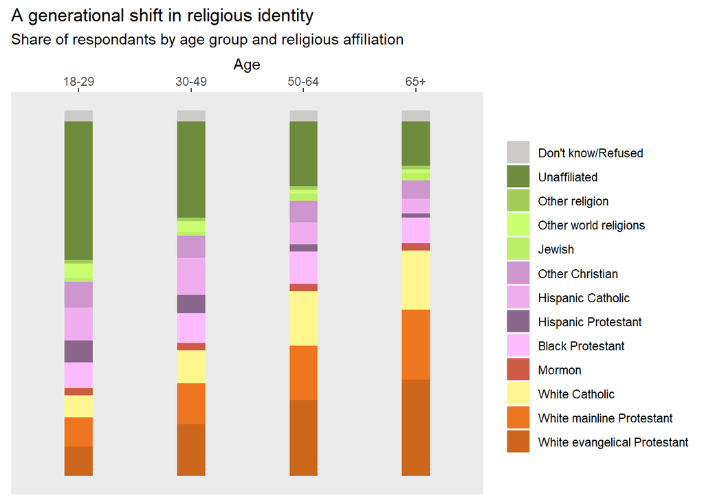

```r
#To build this figure, we need to build upon base ggplot() and add the geom_bar() function.

#We need to figure out how to order the "fills" by religion. The order in the original figure seems to have been alphabetized by ggplot automatically. How do we undo this? - Set religion as a factor.

#COMPLETED
#Load data
#Generate plot
#Reorder the fills
#Add chart labels
#Create a minimal theme by removing all y labels and axes
#Moved X axis to top of chart


#TO-DO
#Find a way to change legend into labels
#Find a way to add data labels inside of the stacks
#Move the "Don't Know/Refused" to the bottom


religion_data_tidy %>%
ggplot(aes(fill= factor(religion, levels=unique(religion)), y= percent, x=age_group)) +
    geom_bar(position="fill", stat="identity", width = 0.25) +
    xlab("Age") +
    ggtitle("A generational shift in religious identity", subtitle = "Share of respondants by age group and religious affiliation") +
    scale_x_discrete(position = "top")+
    theme(axis.title.y = element_blank(), axis.text.y = element_blank(), axis.ticks.y = element_blank(),
    panel.grid.major = element_blank(), panel.grid.minor = element_blank()) +
    guides(fill=guide_legend(title=NULL)) +
  scale_fill_manual(values=c("snow3","darkolivegreen4", "darkolivegreen3","darkolivegreen1", "darkolivegreen2", "plum3", "plum2", "plum4", "plum1","coral3","khaki1", "chocolate2", "chocolate3"))
```

Tried and Failed

1. Adding border around “White evangelical Protestant” - I attempted to add a border by adding an ifelse statement in the geom_bar() function. This included geom_bar(position=“fill”, stat=“identity”, width = 0.25, color = ifelse(religion == “White evangelical Protestant”), “black”, FALSE). This did not work. The religion variable was not identified. The FALSE argument is not possible here, according to the errors (though I have seen color = FALSE used elsewhere)
2. Chaning the Color Pallete - I had a hard time finding this figure’s color pallete or a form of gradient that would work. I went through and hand-picked the colors.
3. Changing Legend - I tried to line up the Legend with the sections of the 65+ bar, as seen in the original figure. I tried this by different variations of geom_text(). One configuration was: geom_text(x == “65+”,label~religion). Did not work here.
4. Adding data labels - There are a few complications with this. The number labels are both black and white.